# Monte Carlo Integration

Amy Chen

October 9, 2018

### Overview

Monte Carlo integration is the statistical estimation of an integral using evaluations of a function with a set of points drawn randomly from a distribution over the range of integration.  
Suppose we are interested in evaluating $\int g(x)\; dx$. If $g(x)$ can be represented as $f(x)h(x)$ where $f(x)$ is a simple probability distribution function, then

$\int_a^b g(x)\; dx = \int_a^b f(x)h(x)\; dx = E_f[h(x)]$

We can approximate $\int g(x) dx$ by drawing an i.i.d. sample from the underlying distribution function $f$, evaluating $h(x)$, and calcuating the average.

### Demonstration

**Suppose we are estimating $\int_1^3 g(x)\; dx$ where $g(x) = \frac{x}{(1+x^2)^2}$**

#### Finding $f$ and $h$

Let $f(x) = \frac{1}{2}$ and $h(x) = 2 \frac{x}{(1+x^2)^2}$.  
Then $\int_1^3 g(x)\; dx = \int_1^3 2 *\frac{1}{2} \frac{x}{(1+x^2)^2}\; dx = E_{f}[2\frac{x}{(1+x^2)^2}\ ], f$~$U(1,3)$

```r
h <- function(x) {
  2*x/(1+x^2)^2;
}
n <- 100000
x <- runif(n, min=1, max=3)
mean(h(x))
```

```
## [1] 0.1997645
```

The true value of the integral is

```r
g <- function(x) {x/(1+x^2)^2}
integrate(g, lower = 1, upper = 3)
```

```
## 0.2 with absolute error < 1.1e-14
```

**Suppose we are estimating $\int_{-\infty}^{\infty} g(x) \; dx$ where $g(x) = x^2e^{-x^2}$**

#### Finding $f$ and $h$

Let $f(x) = \frac{1}{\sqrt{\pi}}e^{-x^2}$ and $h(x) = \sqrt{\pi}x^2$.  
Then $\int_{-\infty}^{\infty} g(x) \; dx = \int_{-\infty}^{\infty} \sqrt{\pi} \frac{1}{\sqrt{\pi}}e^{-x^2}x^2 \; dx = E_{f}[\sqrt{\pi}x^2], f$~$N(0,\sqrt{\frac{1}{2}})$

```r
h <- function(x) {
  sqrt(pi)*x^2;
}
n <- 100000
x <- rnorm(n, 0, sqrt(1/2))
mean(h(x))
```

```
## [1] 0.890181
```

The true value of the integral is

```r
g <- function(x) {x^2*exp(-x^2)}
true_val <- integrate(g, lower = -Inf, upper = Inf)
true_val
```

```
## 0.8862269 with absolute error < 1.1e-06
```

#### Effect of Sample Size

For both of the above examples, a sample size of 100,000 was selected. We shall now examine how the estimation changes as sample size increases for the second example.

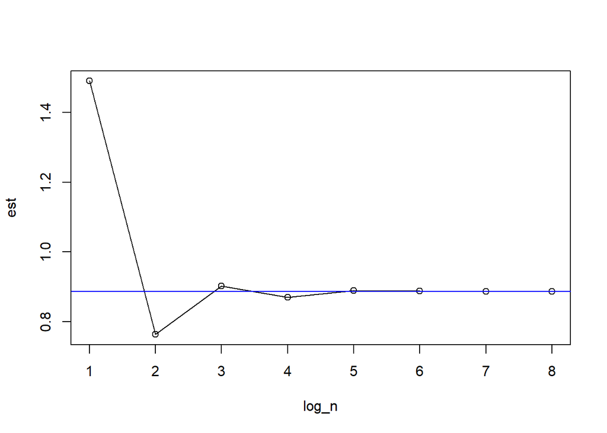

```r
set.seed(20)
h <- function(x) {
  sqrt(pi)*x^2;
}
log_n <- seq(1,8,1)
est <- numeric(8)

for (i in log_n){
  x <- rnorm(10^i,0,sqrt(1/2))
  est[i] = mean(h(x))
}

plot(log_n, est, type="o")
abline(h = true_val$value, col="blue")
```

As sample size increases, the estimate converges to the true integral value.